# Workshop 9 Fiancial Econometrics

Juan David Torres

Apr 21 2021

# Data management

Download data from a website

```r
library(readxl)

download.file("http://www.apradie.com/datos/datamx2020q4.xlsx", "dataw7.xlsx", mode="wb")
data <- read_excel("dataw7.xlsx")
```

Create financial ratios. Create variables for book value, market value, book-to-market value, earnings per share, earnings per share deflated by price.

```r
# Select only active firms:

data <- data[data$status=="active",]

# Create book value variable
data$bookvalue <- data$totalassets-data$totalliabilities

# Calculate marketvalue
data$mktval <- data$originalhistoricalstockprice * data$sharesoutstanding

# Create book-to-market ratio variable
data$bmr <- data$bookvalue / data$mktval

# Create earnings per share variable
data$eps <- data$ebit / data$sharesoutstanding

# Create earnings per share deflated by price column
data$epsp <- data$eps / data$originalhistoricalstockprice
```

Winsorized variable for BMR and EPS with 1%

```r
library(statar)
library(plm)
```

```r
data$bmr_w <- winsorize(data$bmr,probs = c(0.01,0.99))
```

```
0.60 % observations replaced at the bottom
0.60 % observations replaced at the top
```

[figure not shown]

```r
par(mfrow=c(1,2))
hist(data$bmr, col="lightblue", main = "bmr")
hist(data$bmr_w, col = "blue", main="bmr winsorized")
```

```r
data$epsp_w <- winsorize(data$epsp, probs=c(0.01,0.99))
```

```
0.44 % observations replaced at the bottom
0.44 % observations replaced at the top
```

[figure not shown]

```r
par(mfrow=c(1,2))
hist(data$epsp, main = "epsp", col="orange")
hist(data$epsp_w, main="epsp winsorized", col="gold")
```

Set the dataset as a panel data. We will need to use multiple dates

```r
# The index of the data frame must be firmcode-quarter
data <- pdata.frame(data, index = c("firmcode", "quarter"))

# Calculate firm return
data$stockreturn <- diff(log(data$adjustedstockprice))

# We add columns for future returns one year later and one quarter later:
data$F4r <- plm::lag(data$stockreturn,-4)
data$F1r <- plm::lag(data$stockreturn,-1)
```

Binary variable to classify firms according to the size. Small vs big firms

```r
data$size <- log(data$mktval)
# We take the log since the market value variable usually does not
#  behave like a normal distributed variable (it is skewed to the right)
# When we take the log of skewed variables, then the log will behave
#  close to a normal variable



library(dplyr)
# xtile function calculates percentiles by groups. In this case, we
#  group the data by quarter, and for each quarter we will classify
#  firms in 4: very big, big, small, very small
sizetype0 <- data %>%
  group_by(quarter) %>%
  summarise(sizetype = xtile(size, n=4), firmcode=firmcode)
# In this case, n=4 means that it will generate sizetype0 according to
#   the 25 percentile to create 4 groups. Those with values=1 will be
#   the smallest firms and those with values=4 will be the biggest firms.

# Now we merge the panel data with the sizetype0

data <- merge(data,sizetype0,by=c("firmcode","quarter"))

# We again set the data as panel-data since the merge function changed the class of
#   the dataset to data frame:
data <- pdata.frame(data, index = c("firmcode", "quarter"))
```

```r
table(data$sizetype)
```

```
   1    2    3    4
1900 1855 1883 1838
```

# Regression model with categorical variable

Include the new categorical explanatory variables

```r
# Before running a regression with a categorical independent variable,
#  we need to indicate R that this variable is a "factor" variable:
data$size1 <- factor(data$sizetype, c(1,2,3,4), labels = c("Very Small", "Small", "Big", "Very Big"))

# Look at the coding
contrasts(data$size1)
```

```
           Small Big Very Big
Very Small     0   0        0
Small          1   0        0
Big            0   1        0
Very Big       0   0        1
```

Run the regression

```r
# We need to detach (unload) the dplyr library since it makes conflict
#   with the plm package
detach(package:dplyr)

# 4 quarters in the future
reg1 <-plm(lag(stockreturn,-4) ~ size1 + bmr_w, data = data, model="pooling")
reg1results<-summary(reg1)
reg1results
```

```
Pooling Model

Call:
plm(formula = lag(stockreturn, -4) ~ size1 + bmr_w, data = data,
    model = "pooling")

Unbalanced Panel: n = 143, T = 1-76, N = 6577

Residuals:
      Min.    1st Qu.     Median    3rd Qu.       Max.
-1.3004498 -0.0769402 -0.0014358  0.0802195  1.5023835

Coefficients:
                Estimate Std. Error t-value  Pr(>|t|)
(Intercept)   -0.0148149  0.0063925 -2.3176  0.020504 *
size1Small     0.0188085  0.0067562  2.7839  0.005387 **
size1Big       0.0240453  0.0068316  3.5197  0.000435 ***
size1Very Big  0.0290969  0.0072614  4.0071 6.216e-05 ***
bmr_w          0.0165505  0.0026145  6.3302 2.610e-10 ***
---
Signif. codes:
0 ‘***’ 0.001 ‘**’ 0.01 ‘*’ 0.05 ‘.’ 0.1 ‘ ’ 1

Total Sum of Squares:    222.54
Residual Sum of Squares: 221.1
R-Squared:      0.0064381
Adj. R-Squared: 0.0058334
F-statistic: 10.6464 on 4 and 6572 DF, p-value: 1.3426e-08
```

The regression can be runned as weel using the simple lm function, but a variable for future stock returns must be created first

```r
reg2 <-lm(F4r ~ size1 + bmr_w, data = data)
#reg2 <-lm(stockreturn ~ size1 + bmr_w, data = data)
reg2results<-summary(reg2)
reg2results
```

```
Call:
lm(formula = F4r ~ size1 + bmr_w, data = data)

Residuals:
     Min       1Q   Median       3Q      Max
-1.30045 -0.07694 -0.00144  0.08022  1.50238

Coefficients:
               Estimate Std. Error t value Pr(>|t|)
(Intercept)   -0.014815   0.006392  -2.318 0.020504 *
size1Small     0.018808   0.006756   2.784 0.005387 **
size1Big       0.024045   0.006832   3.520 0.000435 ***
size1Very Big  0.029097   0.007261   4.007 6.22e-05 ***
bmr_w          0.016550   0.002615   6.330 2.61e-10 ***
---
Signif. codes:
0 ‘***’ 0.001 ‘**’ 0.01 ‘*’ 0.05 ‘.’ 0.1 ‘ ’ 1

Residual standard error: 0.1834 on 6572 degrees of freedom
  (5583 observations deleted due to missingness)
Multiple R-squared:  0.006438,  Adjusted R-squared:  0.005833
F-statistic: 10.65 on 4 and 6572 DF,  p-value: 1.343e-08
```

Interpret the output of the model

To predict the stock market return with the categorical values two of the three coefficients will be multiplied by 0 so when the prediction wants to be made for small, big and very big it will be done with the following formula: stockPrice = a0 + sizeToBePredicte + bmr_w * bmr and for the very small size it will be stockPrice = a0 +bmr_w * bmr.

Use predictlm to make a prediction of a future stock return with a bmr from 0.6 to 1.6 by 0.1 and for small and big firms.

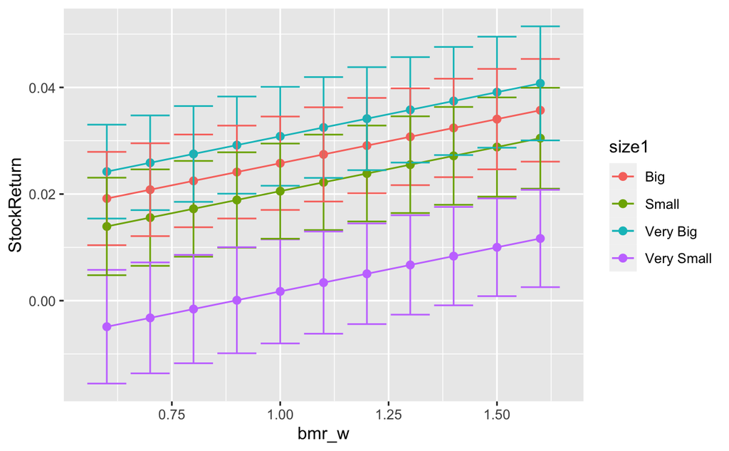

```r
newx <- data.frame(bmr_w = rep(seq(0.6, 1.6, by=0.1), 4), size1 = levels(data$size1))

pr_reg1 <- predict.lm(reg2, newx, interval = "confidence")
colnames(pr_reg1) <- c("StockReturn", "lwr", "upr")
pred_reg1 <- cbind(newx, pr_reg1)

# Plot
library(ggplot2)
ggplot(pred_reg1, aes(x = bmr_w, y=StockReturn, color=size1)) +
  geom_point(size = 2) + geom_line() +
  geom_errorbar(aes(ymax = upr, ymin = lwr))
```

It can be seen that when the bmr increases the stock return also increases. The size of the firm also affects the stock price and as we saw on the equations for the different sizes it can be seen that the vertical distance between very small and small is determined by the coefficient of the size1small. So after considering the effect of the book market return and maintaining the bmr constant it can be said that the distance between each size category is constant which means that it is true that the vertical distance between the very small and any size is determined by its coefficient.

The alpha1 coefficient as we named it is the coefficient for small firms, the coefficient represents the vertical distance between the very small and the small with a bmr constant.

# Evaluating the effect of book-to-market ratio controlling for Industry

Regression model to examine wether the BMR winsorized influences the future stock return one quarter later

```r
table(data$naics1)
```

```
                                         Accommodation and Food Services
                                                                     320
Administrative and Support and Waste Management and Remediation Services
                                                                     160
                              Agriculture, Forestry, Fishing and Hunting
                                                                     160
                                     Arts, Entertainment, and Recreation
                                                                     160
                                                            Construction
                                                                    1360
                                                   Finance and Insurance
                                                                    2640
                                       Health Care and Social Assistance
                                                                      80
                                                             Information
                                                                     800
                                 Management of Companies and Enterprises
                                                                      80
                                                           Manufacturing
                                                                    3120
                           Mining, Quarrying, and Oil and Gas Extraction
                                                                     400
                        Professional, Scientific, and Technical Services
                                                                      80
                                                   Public Administration
                                                                      80
                                      Real Estate and Rental and Leasing
                                                                     720
                                                            Retail Trade
                                                                    1040
                                          Transportation and Warehousing
                                                                     800
                                                               Utilities
                                                                     160
```

```r
# I transform the industry column into a factor column to consider
#   this variable as a categorical variable:
industries<-unique(data$naics1)
# With the unique function I get the unique names of industries from
#   the panel dataset
# I short the name of the 2nd industry to improve the display of the
#  regression models:
industries2<-industries
industries2[2]<-"Administrative and Waste Management"
industries
```

```
 [1] "Manufacturing"
 [2] "Administrative and Support and Waste Management and Remediation Services"
 [3] "Finance and Insurance"
 [4] "Transportation and Warehousing"
 [5] "Construction"
 [6] "Information"
 [7] "Mining, Quarrying, and Oil and Gas Extraction"
 [8] "Agriculture, Forestry, Fishing and Hunting"
 [9] "Retail Trade"
[10] "Accommodation and Food Services"
[11] "Arts, Entertainment, and Recreation"
[12] "Real Estate and Rental and Leasing"
[13] "Utilities"
[14] "Management of Companies and Enterprises"
[15] "Professional, Scientific, and Technical Services"
[16] "Health Care and Social Assistance"
[17] "Public Administration"
```

```r
data$naicsf<-factor(data$naics1,industries,labels=industries2)

reg3<-lm(F1r ~ bmr_w + naicsf, data = data)
summary(reg3)
```

```
Call:
lm(formula = F1r ~ bmr_w + naicsf, data = data)

Residuals:
     Min       1Q   Median       3Q      Max
-1.32226 -0.07538 -0.00606  0.08093  1.46856

Coefficients:
                                                        Estimate
(Intercept)                                             0.011702
bmr_w                                                   0.010409
naicsfAdministrative and Waste Management              -0.014430
naicsfFinance and Insurance                             0.009673
naicsfTransportation and Warehousing                   -0.004392
naicsfConstruction                                     -0.046688
naicsfInformation                                      -0.012114
naicsfMining, Quarrying, and Oil and Gas Extraction    -0.010426
naicsfAgriculture, Forestry, Fishing and Hunting        0.019905
naicsfRetail Trade                                      0.004037
naicsfAccommodation and Food Services                  -0.015823
naicsfArts, Entertainment, and Recreation              -0.027757
naicsfReal Estate and Rental and Leasing               -0.015399
naicsfUtilities                                         0.030428
naicsfManagement of Companies and Enterprises           0.020675
naicsfProfessional, Scientific, and Technical Services  0.003414
naicsfHealth Care and Social Assistance                 0.013675
naicsfPublic Administration                            -0.176974
                                                       Std. Error
(Intercept)                                              0.004624
bmr_w                                                    0.002332
naicsfAdministrative and Waste Management                0.016834
naicsfFinance and Insurance                              0.006758
naicsfTransportation and Warehousing                     0.010670
naicsfConstruction                                       0.007817
naicsfInformation                                        0.009161
naicsfMining, Quarrying, and Oil and Gas Extraction      0.011879
naicsfAgriculture, Forestry, Fishing and Hunting         0.015100
naicsfRetail Trade                                       0.007514
naicsfAccommodation and Food Services                    0.013736
naicsfArts, Entertainment, and Recreation                0.017535
```

[output cut: 56 more lines]

```
naicsfArts, Entertainment, and Recreation
naicsfReal Estate and Rental and Leasing
naicsfUtilities
naicsfManagement of Companies and Enterprises
naicsfProfessional, Scientific, and Technical Services
naicsfHealth Care and Social Assistance
naicsfPublic Administration
---
Signif. codes:
0 ‘***’ 0.001 ‘**’ 0.01 ‘*’ 0.05 ‘.’ 0.1 ‘ ’ 1

Residual standard error: 0.1833 on 7081 degrees of freedom
  (5061 observations deleted due to missingness)
Multiple R-squared:  0.01063,   Adjusted R-squared:  0.008259
F-statistic: 4.477 on 17 and 7081 DF,  p-value: 2.128e-09
```

Interpretation: The coefficients of each of the categorical values represent the vertical distance between that categorical value and the manufacturing category maintaining the bmr constant. After considering the categorical values the bmr when increased by a unit the stock return will change 0.010409.

The regression equation for the Administrative and Waste Management is: stockReturn = 0.011702 - 0.014430 +0.010409 * bmr

# Effect of BMR, EPS and size type on future stock returns

Categorical value for size

```r
library(dplyr)
sizetype1 <- data %>%
  group_by(quarter) %>%
  summarise(sizetype1 = xtile(size, n=3), firmcode=firmcode)
# Now we merge the panel data with sizetype1
data <- merge(data,sizetype1,by=c("firmcode","quarter"))
# We indicate to do the merge by firm-quarter

# The index of the data frame must be firmcode-quarter
data <- pdata.frame(data, index = c("firmcode", "quarter"))

# Code dummy variable
data$size3 <- factor(data$sizetype1, c(1,2,3), labels = c("Small","Medium", "Big"))
# Look at the coding
contrasts(data$size3)
```

```
       Medium Big
Small       0   0
Medium      1   0
Big         0   1
```

Multiple regression model for BMR, EPSP and categorical variable size type

```r
reg4 <- lm(F1r ~ bmr_w + epsp_w + size3, data = data)
summary(reg4)
```

```
Call:
lm(formula = F1r ~ bmr_w + epsp_w + size3, data = data)

Residuals:
     Min       1Q   Median       3Q      Max
-1.29367 -0.07474  0.00327  0.07853  1.50234

Coefficients:
             Estimate Std. Error t value Pr(>|t|)
(Intercept) -0.015913   0.006434  -2.473 0.013429 *
bmr_w        0.006059   0.003335   1.817 0.069314 .
epsp_w       0.106705   0.026620   4.008  6.2e-05 ***
size3Medium  0.021635   0.006526   3.315 0.000922 ***
size3Big     0.022712   0.006951   3.268 0.001091 **
---
Signif. codes:  0 ‘***’ 0.001 ‘**’ 0.01 ‘*’ 0.05 ‘.’ 0.1 ‘ ’ 1

Residual standard error: 0.1815 on 5191 degrees of freedom
  (6964 observations deleted due to missingness)
Multiple R-squared:  0.006195,  Adjusted R-squared:  0.005429
F-statistic: 8.089 on 4 and 5191 DF,  p-value: 1.691e-06
```

We can see in the regression output that after considering the effect of the categorical values and the epsp, an increase of a unit in the bmr increases the stock return by 0.006059. After considering the bmr and the categorical values the epsp when it increases by one unit the stock return changes 0.106705. Additionally the coefficient of both categorical values represent the vertical distance to the sizeSmall.

INTERPRET THE MODEL a) Predict the firm return for a company with a BMR that moves from 0.40 to 1.6 moving by 0.10, and for the 3 size categories. You can do this as:

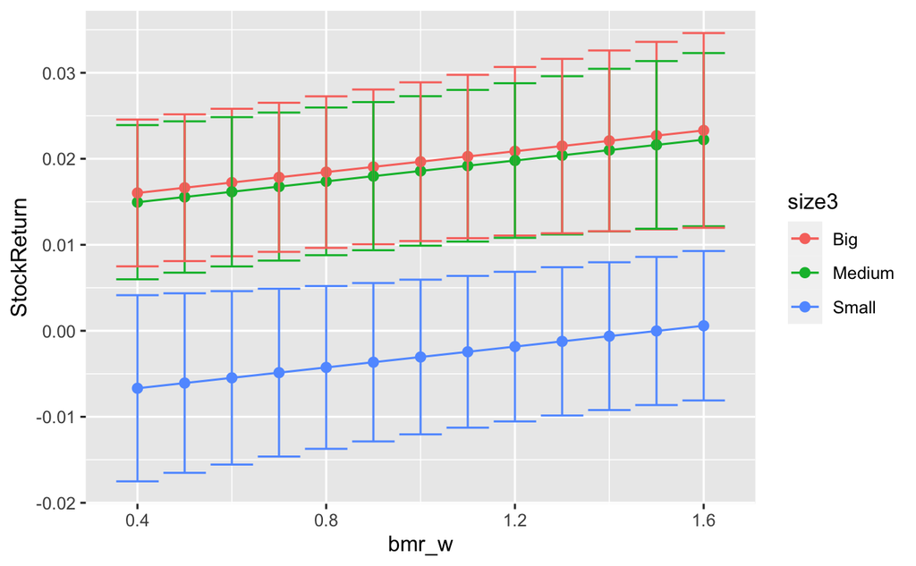

```r
# Make prediction using predict.lm()
newx2 <- data.frame(bmr_w = rep(seq(0.4, 1.6, by=0.1), 3),
                    epsp_w = mean(data$epsp_w,na.rm=TRUE),
                    size3 = levels(data$size3))
pr_reg3 <- predict.lm(reg4, newx2, interval = "confidence")
colnames(pr_reg3) <- c("StockReturn", "lwr", "upr")
pred_reg3 <- cbind(newx2, pr_reg3)

# Plot
ggplot(pred_reg3, aes(x = bmr_w, y=StockReturn, color=size3)) +
  geom_point(size = 2) + geom_line() +
  geom_errorbar(aes(ymax = upr, ymin = lwr))
```

In the graph it can be seen that when the bmr increases the stock return increases. The stock return when the firm is small the 95% interval does not intersect with the other intervals of the other sized firms. The stock return between the medium and big firms isn’t very far from each which means that the size of the firms from medium to big doesnt make much difference.